# FB-PROPHET

### Forecast Diagnostic

It is also useful to quantify the accuracy of our forecasts. We will use the MSE (Mean Squared Error), in which for each predicted value, we compute its distance to the true value and square the result

```python
y_forecasted = pred.predicted_mean[:49]
y_truth = one_step_df.rain_actual
print(y_forecasted.shape)
print(y_truth.shape)
# Compute the mean square error
mse = MSE(y_truth, y_forecasted, squared=True)
print('The Mean Squared Error of our forecasts is {}'.format(round(mse, 2)))
```

```
(49,)
(49,)
The Mean Squared Error of our forecasts is 25.85
```

### Validating the Dynamic Forecast

In this case, we only use information from the time series up to a certain point, and after that, forecasts are generated using values from previous forecasted time points.

```python
pred_dynamic = results.get_prediction(start=0,end = 49, dynamic=True, full_results=True)
pred_dynamic_ci = pred_dynamic.conf_int()
```

```python
pred_dynamic_ci.head()
```

|  | lower rain_actual | upper rain_actual |
| --- | --- | --- |
| 2008-12-02 | -3394.757202 | 3394.757202 |
| 2008-12-03 | -4670.119155 | 4670.119155 |
| 2008-12-04 | -5743.860302 | 5743.860302 |
| 2008-12-05 | -6667.051991 | 6667.051991 |
| 2008-12-06 | -7482.619889 | 7482.619889 |

Once again, we plot the real and forecasted values of the average daily rain to assess how well we did:

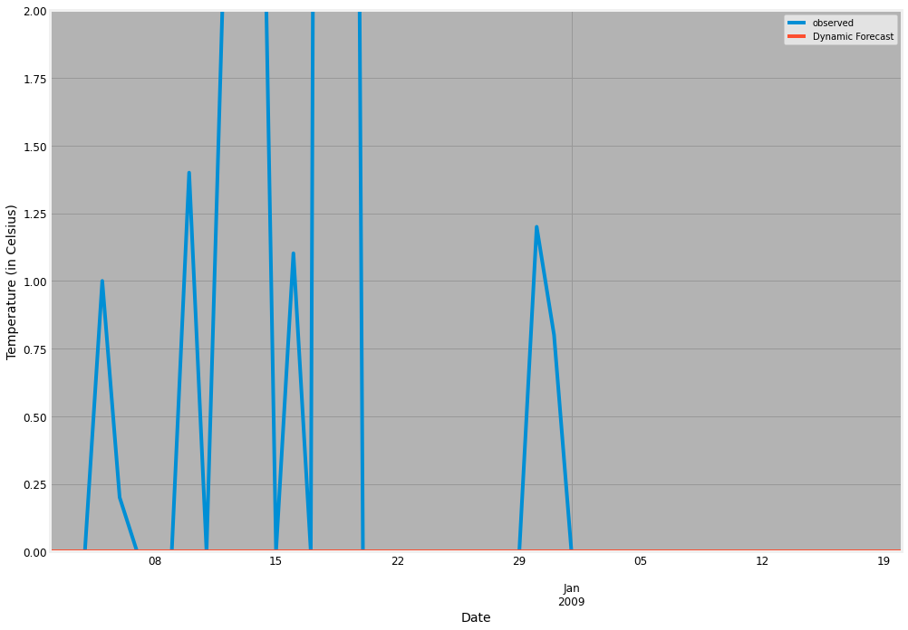

```python
ax = one_step_df.rain_actual.plot(label='observed', figsize=(15, 11))
pred_dynamic.predicted_mean.plot(label='Dynamic Forecast', ax=ax)

ax.fill_between(pred_dynamic_ci.index,
                pred_dynamic_ci.iloc[:, 0],
                pred_dynamic_ci.iloc[:, 1], color='k', alpha=.25)


ax.set_xlabel('Date')
ax.set_ylabel('Temperature (in Celsius)')
plt.ylim([0,2.0])
plt.legend()
plt.show()
```

> In this case, the model seems to predict the rain inaccurately, with major fluctuations between the true value and the predicted value.

### Forecast Diagnostic

```python
# Extract the predicted and true values of our time series
y_forecasted = pred_dynamic.predicted_mean[:49]
y_truth = one_step_df.rain_actual

# Compute the mean square error
mse = sqrt(MSE(y_truth, y_forecasted).mean())
print('The Root Mean Squared Error of our forecasts is {}'.format(round(mse, 2)))
```

```
The Root Mean Squared Error of our forecasts is 3.68
```

# Conclusion

I described how to implement a seasonal SARIMA model in Python. I made extensive use of the pandas and statsmodels libraries and showed how to run model diagnostics, as well as how to produce forecasts of the Rain.